# Dokumentasi Lengkap: Business Framing & Exploratory Data Analysis

## Brazilian E-Commerce Public Dataset (Olist)

## 1. Latar Belakang Bisnis

Sebuah e-commerce marketplace mengalami peningkatan keluhan pelanggan dan pertumbuhan transaksi yang melambat. Terdapat **3 hipotesis bersaing**:

| # | Hipotesis | Argumen |
| --- | --- | --- |
| 1 | **Delivery Delay** | Pengiriman terlambat menyebabkan ketidakpuasan |
| 2 | **Seller/Product Quality** | Kualitas seller/produk buruk → review jelek |
| 3 | **Shipping Cost** | Ongkos kirim mahal menghambat repeat purchase |

**Tujuan:** Memilih **satu framing** yang paling didukung data.

## 2. Dataset yang Digunakan

### Tabel Inti (di-join untuk analisis utama)

| # | File | Baris | Kolom Kunci | Peran |
| --- | --- | --- | --- | --- |
| 1 | olist_orders_dataset.csv | 99,441 | `order_id`, tanggal pembelian/kirim/estimasi, `order_status` | Tabel utama order |
| 2 | olist_order_items_dataset.csv | 112,650 | `order_id`, `price`, `freight_value`, `seller_id`, `product_id` | Detail item & harga |
| 3 | olist_order_payments_dataset.csv | 103,886 | `order_id`, `payment_value`, `payment_installments` | Data pembayaran |
| 4 | olist_order_reviews_dataset.csv | 99,224 | `order_id`, `review_score` (1-5), `review_comment_message` | Feedback pelanggan |

### Tabel Pendukung (untuk analisis kualitas seller)

| # | File | Baris | Peran |
| --- | --- | --- | --- |
| 5 | olist_products_dataset.csv | 32,951 | Nama kategori produk |
| 6 | olist_sellers_dataset.csv | 3,095 | Lokasi seller |
| 7 | product_category_name_translation.csv | 71 | Terjemahan kategori (Portugis → Inggris) |

> [!NOTE] olist_customers_dataset.csv dan olist_geolocation_dataset.csv di-load tetapi tidak digunakan dalam analisis inti.

## 3. Preprocessing

### 3.1 Konversi Tipe Data

5 kolom tanggal dikonversi dari `string` → `datetime`:

```python
for col in ['order_purchase_timestamp', 'order_approved_at',
            'order_delivered_carrier_date', 'order_delivered_customer_date',
            'order_estimated_delivery_date']:
    orders[col] = pd.to_datetime(orders[col])
```

### 3.2 Agregasi `order_items` (many-to-one → 1 baris per order)

Satu order bisa memiliki banyak item. Diagregasi menjadi:

```python
items_agg = items.groupby('order_id').agg(
    total_items   = ('order_item_id', 'count'),   # jumlah item
    total_price   = ('price', 'sum'),              # total harga barang
    total_freight  = ('freight_value', 'sum'),     # total ongkir
)
```

### 3.3 Agregasi `payments` (bisa >1 pembayaran per order)

```python
payments_agg = payments.groupby('order_id').agg(
    payment_value        = ('payment_value', 'sum'),
    payment_installments = ('payment_installments', 'max'),
)
```

### 3.4 Deduplikasi `reviews`

Beberapa order punya review duplikat → diambil review **terakhir**:

```python
reviews_dedup = reviews.sort_values('review_creation_date') \
                       .drop_duplicates(subset='order_id', keep='last')
```

### 3.5 Join (Inner Join via `order_id`)

```
orders ──→ items_agg ──→ payments_agg ──→ reviews_clean
         inner join     inner join       inner join
```

Hasil: **97,916 baris** (berkurang dari 99,441 karena order tanpa item/pembayaran/review ter-drop)

### 3.6 Filter Delivered Orders

```python
delivered = df[df['order_status'] == 'delivered'].dropna(subset=['delivery_duration'])
# Hasil: 95,823 baris
```

### 3.7 Outlier Handling

```python
df['freight_ratio'] = df['freight_ratio'].clip(upper=5)  # cap di 500%
```

> **Ringkasan:** Preprocessing minimal dan transparan — konversi tipe, agregasi, deduplikasi, filter, dan 1 outlier cap. Tidak ada imputasi atau transformasi kompleks.

## 4. Feature Engineering

### Delivery (Hipotesis 1)

| Variabel | Formula | Keterangan |
| --- | --- | --- |
| `delivery_duration` | `delivered_date − purchase_date` (hari) | Durasi pengiriman total |
| `delivery_delay` | `delivery_duration − estimated_duration` | Keterlambatan (>0 = terlambat) |
| `timeliness_status` | `Late` jika delay > 0, `On-Time` jika ≤ 0 | Label kategorikal |

### Quality (Hipotesis 2)

| Variabel | Formula |
| --- | --- |
| `review_category` | `Bad (1-2)`, `Neutral (3)`, `Good (4-5)` |

### Shipping Cost (Hipotesis 3)

| Variabel | Formula |
| --- | --- |
| `freight_ratio` | `total_freight / total_price` |
| `shipping_category` | `Low (<15%)`, `Medium (15-30%)`, `High (>30%)` |

### Statistik Deskriptif

| Metrik | Nilai |
| --- | --- |
| Order delivered | **95,823** |
| Order terlambat | **7,660 (8.0%)** |
| Rata-rata durasi kirim | **12.5 hari** |
| Rata-rata freight ratio | **30.8%** |
| Review skor 5 | **56,931 (58.1%)** |
| Review skor 1 | **10,825 (11.1%)** |

## 5. Analisis Eksplorasi — Hipotesis 1: Delivery Delay

### Review Score berdasarkan Ketepatan Waktu

| Status | Mean Score | Median | Jumlah Order |
| --- | --- | --- | --- |
| **On-Time** | **4.29** | 5.0 | 88,163 |
| **Late** | **2.57** | 2.0 | 7,660 |

> [!IMPORTANT] Gap **1.73 poin** — perbedaan terbesar yang ditemukan di seluruh analisis.

### Statistik Keterlambatan

- Rata-rata terlambat: **9.4 hari** | Median: **5.8 hari** | Terburuk: **189 hari**

### Tren Late Rate (2018)

| Bulan | Order | Late | Rate |
| --- | --- | --- | --- |
| Mar 2018 | 6,948 | 1,463 | **21.1%** |
| Jun 2018 | 6,072 | 83 | **1.4%** |
| Agu 2018 | 6,330 | 651 | **10.3%** |

Late rate sangat **volatil** (1.4%–21.1%) → ketidakstabilan logistik sistemik.

## 6. Analisis Eksplorasi — Hipotesis 2: Seller/Product Quality

### Distribusi Review Score

| Skor | Persentase |
| --- | --- |
| 5 | **58.1%** |
| 4 | 19.4% |
| 3 | 8.3% |
| 1-2 | **14.2%** |

Mayoritas pelanggan puas (77.5% skor 4-5). Bad reviews terkonsentrasi: **111 seller (5.8%)** = **50% bad reviews**.

## 7. Analisis Eksplorasi — Hipotesis 3: Shipping Cost

### Review Score berdasarkan Kategori Ongkir

| Kategori | Mean Score | Order Count |
| --- | --- | --- |
| Low (<15%) | 4.20 | 28,909 |
| Medium (15-30%) | 4.16 | 33,256 |
| High (>30%) | 4.11 | 33,658 |

Gap low vs high hanya **0.08 poin** — praktis **tidak signifikan**.

## 8. Validasi Statistik untuk Pemilihan Framing

> **Mengapa non-parametrik?** Review score bersifat **ordinal** (1-5) — bukan interval/rasio. Uji non-parametrik tidak mengasumsikan normalitas atau jarak yang setara antar skor, sehingga lebih valid secara metodologis.

### 8.1 Mann-Whitney U Test — Delivery (On-Time vs Late)

**H₀:** Distribusi review score On-Time = Late | **H₁:** Berbeda

| Grup | n | Mean | Median |
| --- | --- | --- | --- |
| On-Time | 88,163 | 4.29 | 5.0 |
| Late | 7,660 | 2.57 | 2.0 |

| Statistik | Nilai |
| --- | --- |
| U statistic | 524,563,210 |
| **p-value** | **< 0.001** |
| **Effect size (rank-biserial r)** | **−0.554 (LARGE)** |

> **Keputusan:** TOLAK H₀. Review score on-time **berbeda signifikan** dari late, dengan effect size **LARGE**.

### 8.2 Mann-Whitney U Test — Shipping (Low vs High)

**H₀:** Distribusi review score Low shipping = High shipping

| Grup | n | Mean |
| --- | --- | --- |
| Low (<15%) | 28,909 | 4.20 |
| High (>30%) | 33,658 | 4.11 |

| Statistik | Nilai |
| --- | --- |
| **p-value** | **< 0.001** |
| **Effect size (rank-biserial r)** | **−0.038 (NEGLIGIBLE)** |

> **Keputusan:** Meskipun p < 0.05, effect size **NEGLIGIBLE**. Signifikansi statistik disebabkan oleh sample size besar (n > 60K), **bukan** perbedaan yang bermakna secara praktis.

### 8.3 Kruskal-Wallis H Test — 3 Kategori Shipping

**H₀:** Distribusi review score sama di semua kategori shipping

| Statistik | Nilai |
| --- | --- |
| H statistic | 87.72 |
| p-value | < 0.001 |
| **Effect size (epsilon-squared)** | **0.0009 (NEGLIGIBLE)** |

> Secara statistik signifikan, tapi effect size **hampir nol** → tidak bermakna secara bisnis.

### 8.4 Chi-Square Test — Proporsi Bad Review

**H₀:** Proporsi bad review independen dari ketepatan waktu

| Status | Good/Neutral (3-5) | Bad (1-2) | Bad Rate |
| --- | --- | --- | --- |
| On-Time | 80,032 | 8,131 | **9.2%** |
| Late | 3,520 | 4,140 | **54.0%** |

| Statistik | Nilai |
| --- | --- |
| Chi-square | 12,677.62 |
| **p-value** | **< 0.001** |
| **Cramer's V** | **0.364 (MEDIUM)** |

> Order terlambat memiliki probabilitas bad review **5.9× lebih tinggi** dibanding on-time. Effect size MEDIUM.

### 8.5 Spearman Rank Correlation

| Variabel | Spearman rs | p-value | Magnitude |
| --- | --- | --- | --- |
| **Delivery Duration** vs Review | **−0.235** | < 0.001 | **WEAK-MODERATE** |
| Freight Ratio vs Review | −0.031 | < 0.001 | VERY WEAK |

### 8.6 Ringkasan Effect Size — Dasar Pemilihan Framing

| Hipotesis | Test | Effect Size | Magnitude |
| --- | --- | --- | --- |
| **DELIVERY** | Mann-Whitney U (On-Time vs Late) | **r = 0.554** | **LARGE** |
| **DELIVERY** | Chi-Square (bad review proportion) | **V = 0.364** | **MEDIUM** |
| **DELIVERY** | Spearman correlation | **rs = 0.235** | WEAK-MODERATE |
| Shipping | Mann-Whitney U (Low vs High) | r = 0.038 | NEGLIGIBLE |
| Shipping | Kruskal-Wallis (3 categories) | ε² = 0.001 | NEGLIGIBLE |
| Shipping | Spearman correlation | rs = 0.031 | VERY WEAK |

> [!IMPORTANT] **Delivery Delay** memiliki effect size **LARGE** dan **MEDIUM** pada uji inferensial, sementara **Shipping Cost** menunjukkan effect size **NEGLIGIBLE** di semua uji. Keputusan pemilihan framing ini **bukan hanya berdasarkan p-value** (yang mudah signifikan di n besar), melainkan berdasarkan **effect size** — ukuran yang lebih bermakna secara praktis.

### Interpretasi Skala Effect Size

| Ukuran | Negligible | Small | Medium | Large |
| --- | --- | --- | --- | --- |
| Rank-biserial r | < 0.1 | 0.1–0.3 | 0.3–0.5 | > 0.5 |
| Cramer's V | < 0.1 | 0.1–0.3 | 0.3–0.5 | > 0.5 |
| Epsilon-squared | < 0.01 | 0.01–0.06 | 0.06–0.14 | > 0.14 |
| Spearman rs | < 0.1 | 0.1–0.3 | 0.3–0.5 | > 0.5 |

## 9. Interpretasi Visualisasi

### Chart 1 — Baseline: Delivery Duration by Review Score

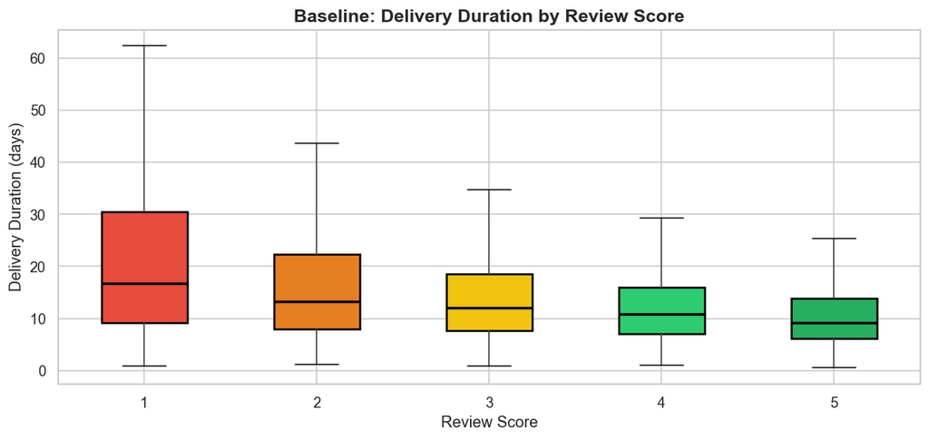

**Apa yang ditampilkan:** Boxplot distribusi durasi pengiriman (hari) per review score (1-5).

**Interpretasi:** - Pola **gradien monoton** yang jelas: semakin rendah skor, semakin lama pengiriman - **Skor 1:** median ~17 hari, IQR 10–30 hari, whisker >60 hari - **Skor 5:** median ~9 hari, IQR 5–14 hari - **Kesimpulan:** Durasi pengiriman adalah **prediktor kuat** kepuasan pelanggan. Pelanggan yang menunggu lebih lama secara sistematis memberikan skor lebih rendah.

### Chart 2 — On-Time vs Late + Monthly Trend

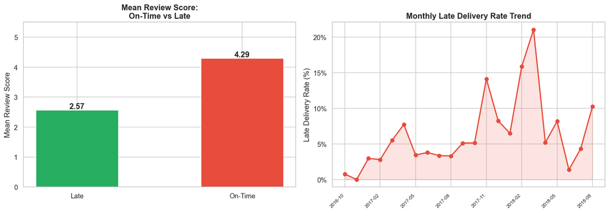

**Panel Kiri (Bar Chart):** - On-Time: **4.29** vs Late: **2.57** — gap 1.73 poin - Skor 2.57 berada **di bawah netral (3)** → pelanggan terlambat **secara aktif tidak puas**

**Panel Kanan (Line Chart):** - Late rate berfluktuasi drastis: puncak **21.1%** (Mar 2018) → turun ke **1.4%** (Jun 2018) → naik lagi **10.3%** - **Kesimpulan:** Masalah logistik **sistemik dan berulang**, bukan insiden satu kali

### Chart 3 — Distribution of Review Scores

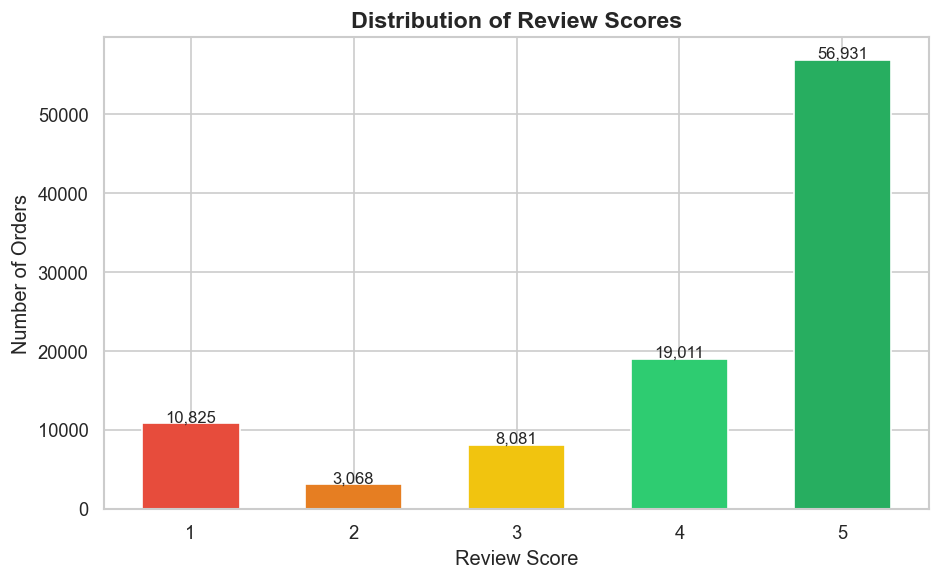

### Chart 4 — Shipping Cost Analysis

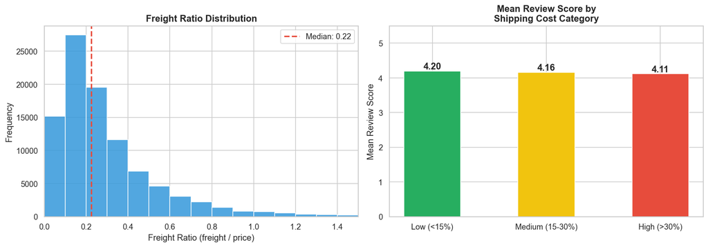

**Panel Kiri (Histogram):** Freight ratio right-skewed, median 0.22 (22%), mayoritas 10-30%

**Panel Kanan (Bar Chart):** Low 4.20, Medium 4.16, High 4.11 — **perbedaan visual hampir tidak terlihat**

## 10. Decision Memorandum

### Decision Statement

Masalah bisnis utama adalah **keterlambatan pengiriman**, yang menyebabkan penurunan skor review 1.73 poin.

### Chosen Framing: Delivery Delay

| Hipotesis | Bukti Utama | Uji Statistik | Effect Size |
| --- | --- | --- | --- |
| **Delivery Delay** | Late: 2.57 vs On-time: 4.29; bad rate 54% vs 9.2% | Mann-Whitney U, Chi-Square | **LARGE (r=0.554), MEDIUM (V=0.364)** |
| Seller Quality | 5.8% seller = 50% bad reviews; tapi 77.5% positif | — (deskriptif) | Moderat |
| Shipping Cost | Gap hanya 0.08 poin | Mann-Whitney U, Kruskal-Wallis | **NEGLIGIBLE (r=0.038, ε²=0.001)** |

### Business Recommendation

**Minggu ini:** Implementasi dashboard monitoring pengiriman, flagging order berisiko terlambat, renegosiasi SLA dengan mitra logistik pada rute terburuk.

### Three Alternative Actions

| Opsi | Tindakan | Trade-offs |
| --- | --- | --- |
| **A. Fix Delivery** ✅ | Monitoring logistik, SLA ketat, estimasi realistis | Biaya moderat, atasi driver #1 |
| **B. Tindak Seller** | Batasi 111 seller terburuk | Quick win, tapi kurangi supply |
| **C. Do Nothing** | Status quo | Keluhan terus tumbuh |

### Primary Success Metric

**On-time delivery rate** — saat ini **92%**, target **≥ 97%** dalam 3 bulan.

### Risk if Wrong

Jika delivery bukan akar masalah, investasi logistik tak mengatasi 5.8% seller bermasalah. **Mitigasi:** pilot paralel batasi 50 seller terburuk sambil perbaiki logistik.

## 11. Appendix: Data Evidence

### Baseline Visualization

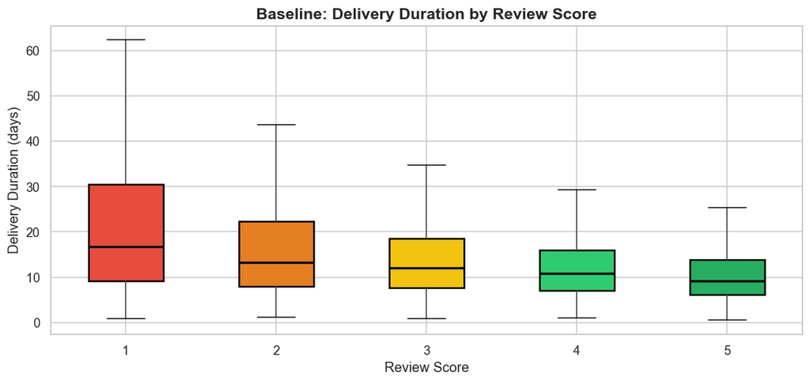

### Comparison Table 1

| Status | Mean Score | Median | Order Count |
| --- | --- | --- | --- |
| **On-Time** | **4.29** | 5.0 | 88,163 |
| **Late** | **2.57** | 2.0 | 7,660 |

### Comparison Table 2

| Bulan | Total | Late | Rate |
| --- | --- | --- | --- |
| Mar 2018 | 6,948 | 1,463 | **21.1%** |
| Apr 2018 | 6,752 | 351 | 5.2% |
| Mei 2018 | 6,722 | 550 | 8.2% |
| Jun 2018 | 6,072 | 83 | 1.4% |
| Jul 2018 | 6,118 | 266 | 4.3% |
| Agu 2018 | 6,330 | 651 | **10.3%** |

### Bukti Terkuat

Bukti paling compelling adalah hasil **Mann-Whitney U test** yang menunjukkan effect size **LARGE (r = 0.554)** untuk perbedaan review score antara on-time (4.29) dan late (2.57). Uji **Chi-Square** mengkonfirmasi bahwa order terlambat memiliki **probabilitas bad review 5.9× lebih tinggi** (54.0% vs 9.2%) dengan Cramer's V = 0.364 (MEDIUM). Sebaliknya, seluruh uji statistik untuk shipping cost menghasilkan effect size **NEGLIGIBLE** (r = 0.038, ε² = 0.001). Keputusan ini bukan hanya berdasarkan p-value yang mudah signifikan pada n besar, melainkan berdasarkan **effect size** yang mencerminkan dampak praktis. **Delivery delay adalah pendorong utama keluhan pelanggan.**

*Script: olist_business_analysis.py | Data: 97,916 orders, Brazilian E-Commerce Public Dataset (Olist)*